# Alcohol vs. Happiness: an Investigation into Alcoholism

- Show All Code
- Hide All Code
- View Source

Author

Adam Del Rio, Dillon Murphy, Ruben Jimenez, Nick Patrick

## Introduction

The “happiness score” dataset measures the national average response to a Cantril life ladder survey from 2004 to 2020. The Cantril life ladder is a well-being quantitative assessment based on an imaginary step ladder where the bottom rung is minimum life satisfaction (0) and the top rung is the best possible life satisfaction (10), explained further [here.](https://news.gallup.com/poll/122453/understanding-gallup-uses-cantril-scale.aspx.) Scores were then scaled from 0-100 to effectively communicate percentages.

The “alcohol consumption per capita” dataset measures projected estimates for the quantity of alcohol consumed in people over the age of 15 from 1999 to 2017, in liters. Data were collected quinquennially, with the exception of the 2014-2017 timespan, where data were collected triennially.

## Data

Both datasets were pivoted longer, and “year” columns were converted to numeric variables. We also realized there was not much justification to keeping the many years from the alcohol dataset that were entirely missing.

```r
# Pivoting Longer, convert years to numeric and dropping unnecessary missing alcohol columns
alc_final <- alc |>
  select("country", "1999", "2004", "2009", "2014", "2017") |>
  pivot_longer(cols = "1999":"2017",
               names_to = "year",
               values_to = "alcohol_consumption")|>
  mutate(
    across("year", as.numeric))


happy_final <- happy |>
  pivot_longer(cols = `2004`:`2020`,
               names_to = "year",
               values_to = "happiness_score")|>
  mutate(
    across("year", as.numeric))
```

Then, we joined the datasets using an inner join so we could keep only the years both datasets had in common.

```r
# Inner Joining the data
final_data <- inner_join(happy_final, alc_final, by = c("year", "country"))
final_data |>
  datatable(class = "cell-border stripe hover",
                   colnames = c("Country",
                                "Year",
                                "Mean Happiness Score",
                                "Mean Alcohol Consumption"),
                   rownames = FALSE,
                   options = list(paging = TRUE,
                                  searching = TRUE,
                                  info = TRUE))
```

| Country | Year | Mean Happiness Score | Mean Alcohol Consumption |
| --- | --- | --- | --- |
| Afghanistan | 2004 |  |  |
| Afghanistan | 2009 | 47.6 | 0.21 |
| Afghanistan | 2014 | 39.8 | 0.21 |
| Afghanistan | 2017 | 26.9 | 0.21 |
| Angola | 2004 |  | 4.89 |
| Angola | 2009 |  | 8.16 |
| Angola | 2014 |  | 7.96 |
| Angola | 2017 |  | 6.94 |
| Albania | 2004 |  | 7.65 |
| Albania | 2009 | 52.7 | 7.69 |

[output cut: 626 more lines]

## Linear Regression

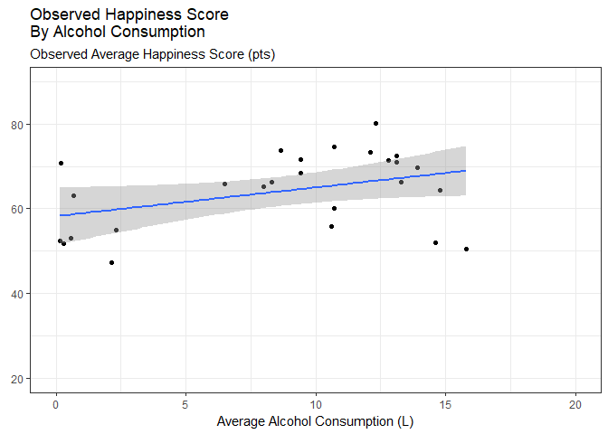

```r
# Font formatting credit: https://ggplot2.tidyverse.org/articles/faq-customising.html
actual_reg <- ggplot(data = final_data, mapping = aes(x = alcohol_consumption, y = happiness_score)) +
  geom_point() +
  geom_smooth(method = "lm") +
  labs(title = "Observed Happiness Score\nBy Alcohol Consumption",
       x = "Average Alcohol Consumption (L)",
       subtitle = "Observed Average Happiness Score (pts)",
       y= NULL) +
  theme_bw(base_family = "Times New Roman") +
  scale_x_continuous(limits = c(0, 20)) +
  scale_y_continuous(limits = c(20, 90))
animate(actual_reg + transition_states(year,
    transition_length = 2,
    state_length = 1
  ), fps = 15, duration = 15, renderer = gifski_renderer())
```

Based on our linear regression model investigating the strength of the association between alcohol consumption per capita and happiness score by each year, we can see that there is a weak positive association between these variables every year. Overall, there is likely a weak positive association between alcohol consumption per capita and happiness score.

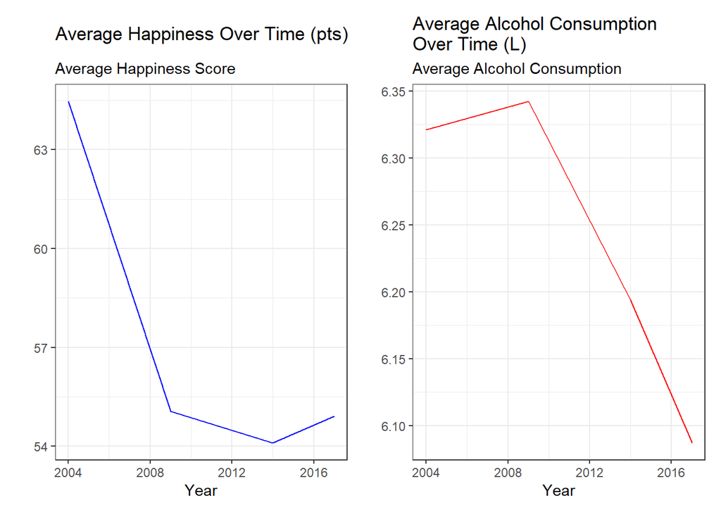

```r
average_year <- final_data |>
  group_by(year) |>
  summarize(mean_happy = mean(happiness_score, na.rm = TRUE),
            mean_alc = mean(alcohol_consumption, na.rm = TRUE))

plot1 <- ggplot(data = average_year, mapping = aes(x = year, y = mean_happy)) +
  geom_line(color = "blue") +
  labs(title = "Average Happiness Over Time (pts)",
       x = "Year",
       y= "",
       subtitle = "Average Happiness Score") +
  theme_bw(base_family = "Times New Roman")

plot2 <- ggplot(data = average_year, mapping = aes(x = year, y = mean_alc)) +
  geom_line(color = "red") +
  labs(title = "Average Alcohol Consumption \nOver Time (L)",
       x = "Year",
       y= "",
       subtitle = "Average Alcohol Consumption") +
  theme_bw(base_family = "Times New Roman")

plot1 + plot2
```

For the plots above, we grouped the observations by year and found the mean happiness score and mean alcohol consumption per capita in liters. Based on our time series plots for mean happiness score and mean alcohol consumption per capita, both happiness and alcohol consumption have decreased over time. From 2004-2009, happiness decreased very rapidly from an average score around 64 happiness points all the way down to about 55 happiness points. Meanwhile average alcohol consumption was actually increasing very slightly. Past 2009, average happiness began to level off, and even increases after 2014. On the other hand, average alcohol consumption rapidly dropped from just under 6.35 liters per capita down to less than 6.1 liters.

## Model Fit

```r
my_model <- lm(happiness_score ~ alcohol_consumption,
               data = final_data
               )
my_model |>
  tidy() |>
  mutate(term = case_when(term == "alcohol_consumption" ~ "Alcohol Consumption",
                   term == "(Intercept)" ~ "Intercept")) |>
  kbl(col.names = c("Term",
                    "Estimate",
                    "Standard Error",
                    "Statistic",
                    "P-value"),
      caption = "Regression Output",
      digits = 4) |>
  kable_classic_2(html_font = "Times New Roman",
                  lightable_options = "striped")
```

Regression Output

| Term | Estimate | Standard Error | Statistic | P-value |
| --- | --- | --- | --- | --- |
| Intercept | 48.5803 | 0.9257 | 52.4776 | 0 |
| Alcohol Consumption | 1.0012 | 0.1157 | 8.6560 | 0 |

$$\widehat{happiness~score} = 1.001167(alcohol~consumption) + 48.580332$$

```r
augmented <- augment(my_model)
response_var <- var(augmented$happiness_score) |>
  round(digits = 3)
fitted_var <- var(augmented$.fitted) |>
  round(digits = 3)
residual_var <- var(augmented$.resid) |>
  round(digits = 3)
table <- data.frame(response_var, fitted_var, residual_var)
table |>
  kbl(col.names = c("Variation in Response",
                  "Variation in the Fitted Values",
                  "Variation in the Residuals"),
      caption = "Variation",
      digits = 3) |>
  kable_classic_2(html_font = "Times New Roman",
                  lightable_options = "striped")
```

Variation

| Variation in Response | Variation in the Fitted Values | Variation in the Residuals |
| --- | --- | --- |
| 127.019 | 19.307 | 107.711 |

```r
model_fit <- round((fitted_var/(response_var))*100,
                   digits = 3)
```

By dividing the amount of variation in the fitted values (values from our predictive model) by the total variation in the observed responses, we obtain an $R^{2}$ statistic representing the amount of variation explained by our model. In other words, this statistic explains how well our model can predict the pattern in the data. Based on the $R^{2}$ we calculated for the model we fit, only 15.2% of variability in the response values were accounted for by the regression model. With such a low $R^{2}$ this confirms that our model is unfit for the data.

## Simulation

```r
noise <- function(x, mean = 0, sd){
  x + rnorm(length(x),
            mean,
            sd)
}

sim <- function(){
  preds <- predict(my_model)

  sd <- sigma(my_model)

  tibble(sim_happiness_score = noise(preds, sd = sd))
}
```

```r
set.seed(1234)
final_preds <- sim()
new <- final_data |> na.omit(alcohol_consumption)

simulated <- final_preds |> mutate(
  alcohol_consumption = new$alcohol_consumption
)
```

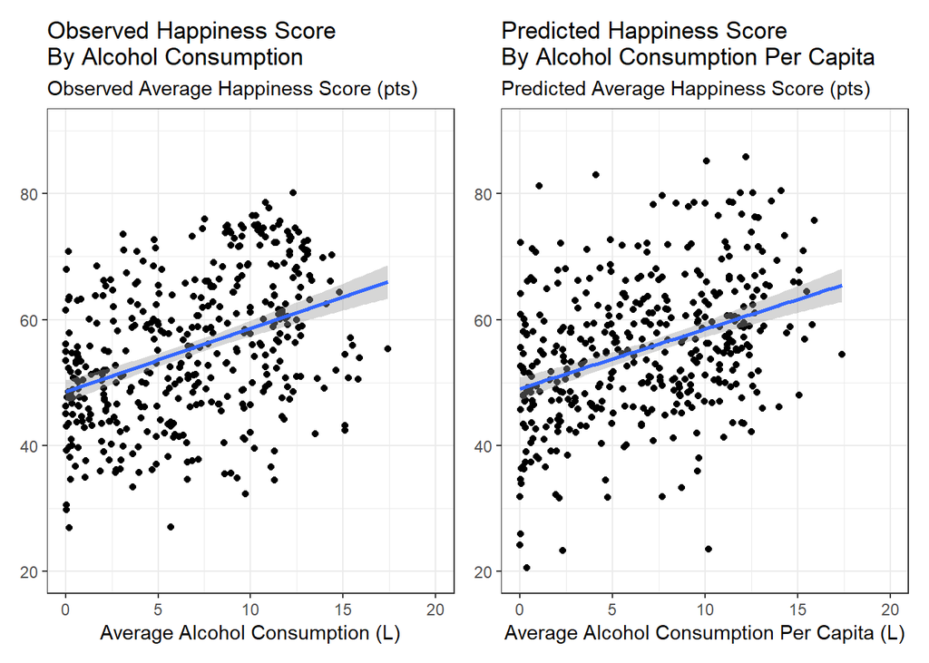

```r
sim_reg <- ggplot(data = simulated, mapping = aes(x = alcohol_consumption, y = sim_happiness_score)) +
  geom_point() +
  geom_smooth(method = "lm") +
  labs(title = "Predicted Happiness Score\nBy Alcohol Consumption Per Capita",
       x = "Average Alcohol Consumption Per Capita (L)",
       subtitle = "Predicted Average Happiness Score (pts)",
       y= NULL) +
  theme_bw(base_family = "Times New Roman") +
  scale_x_continuous(limits = c(0, 20)) +
  scale_y_continuous(limits = c(20, 90))

actual_reg + sim_reg
```

```r
r2s <- vector()
for (i in c(1:1000)){
  predicted <- sim()
  sim_data <- new |>
    select(happiness_score) |>
    na.omit() |>
    bind_cols(predicted)

  sim_r2 <- lm(happiness_score ~ sim_happiness_score,
               data = sim_data
               ) |>
    glance() |>
    select(r.squared) |>
    pull()
  r2s <- append(r2s, sim_r2)
}
```

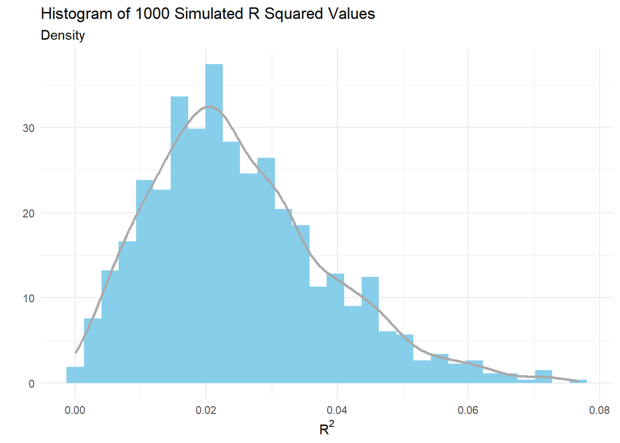

```r
ggplot(data = tibble(r2s), mapping = aes(x = r2s)) +
  geom_histogram(aes(y = ..density..), fill = "skyblue") +
  geom_density(color = "darkgrey", size = 1) +
  theme_minimal(base_family = "Times New Roman") +
  labs(x = bquote(R^2), y = "", title = "Histogram of 1000 Simulated R Squared Values",
       subtitle = "Density")
```

Based on the distribution of 1000 very small $R^{2}$ values of < 0.1 from the regressions, we can see that the model does not generate data that is remotely similar to what was observed. Less than 10% of the variation in the observed happiness scores can be explained by the predicted happiness score for all 1000 simulations. This makes sense since there did not end up being a pattern among the data or any large association between alcohol consumption per capita and happiness score. Since the plot was so scattered with no apparent pattern, it would be hard for any model to be able to predict the observations.

## Conclusion

Based on the regression coefficient = 1.001 we got from our regression model, we expected there to be a very weak positive association between alcohol consumption per capita and happiness score. However, upon inspecting the regression model’s fit to the data, we found the $R{^2}$ statistic to be .152, which means that only 15.2% of the variability in the happiness scores can actually be explained by alcohol consumption. This means there are likely many sources of extraneous variability; that is, many other factors that may impact happiness scores. So, as it turns out, we can’t necessarily use alcohol consumption per capita to predict happiness score within a country. Experimentation using random assignment, data collection with more observations, and the inclusion of possible interactions would likely improve the accuracy of the model we fit and allow us to get a better understanding of the association between alcohol consumption and happiness score.